# Final Exam Winter 2018

Lake Vitton

April 17, 2018

> Welcome to the Final Exam for Winter 2018. Your exam submission will consist of an edited version of this RMD file and its HTML output. Please upload both these files to Canvas before the deadline.

> Please note that you are expected to provide text comments, interpretations and explanations everywhere. Please explain your work. Spend some time interpreting your output and thinking about the business and decision making implications of your output.

> Finally, the specifications in this file are the baseline requirements for the final. If you can finish the file - then that’s perfect. However, feel free to go beyond the specs in this file. For example - build a case for Cost Matrix for Decision Trees and add that. Cost Matrix is not part of this specification - but doing this may get you some extra credit points.

## Identifying Phishing Websites

For this final, we are using the dataset previously provided to you that contained information regarding various website attributes and a response variable: whether a website is a phishing website. Your objective today is to use the class content to build predictive models that can help us predict whether a particular website is a phishing website or not.

Let’s upload the dataset and see what we got here:

```r
phish <- read.csv("phishing.csv")
str(phish)
```

```
## 'data.frame':    11055 obs. of  31 variables:
##  $ having_IP_Address          : int  -1 1 1 1 1 -1 1 1 1 1 ...
##  $ URL_Length                 : int  1 1 0 0 0 0 0 0 0 1 ...
##  $ Shortining_Service         : int  1 1 1 1 -1 -1 -1 1 -1 -1 ...
##  $ having_At_Symbol           : int  1 1 1 1 1 1 1 1 1 1 ...
##  $ double_slash_redirecting   : int  -1 1 1 1 1 -1 1 1 1 1 ...
##  $ Prefix_Suffix              : int  -1 -1 -1 -1 -1 -1 -1 -1 -1 -1 ...
##  $ having_Sub_Domain          : int  -1 0 -1 -1 1 1 -1 -1 1 -1 ...
##  $ SSLfinal_State             : int  -1 1 -1 -1 1 1 -1 -1 1 1 ...
##  $ Domain_registeration_length: int  -1 -1 -1 1 -1 -1 1 1 -1 -1 ...
##  $ Favicon                    : int  1 1 1 1 1 1 1 1 1 1 ...
##  $ port                       : int  1 1 1 1 1 1 1 1 1 1 ...
##  $ HTTPS_token                : int  -1 -1 -1 -1 1 -1 1 -1 -1 1 ...
##  $ Request_URL                : int  1 1 1 -1 1 1 -1 -1 1 1 ...
##  $ URL_of_Anchor              : int  -1 0 0 0 0 0 -1 0 0 0 ...
```

[output cut: 17 more lines]

As you can see, we have 31 variables including the response variable “Result”. As the provided document explained, each of the predictor variables is an evaluation of whether a specific website attribute indicates that the website is:

- Legitimate (indicated by value: -1)
- Suspicious (indicated by value: 0)
- Phishing (indicated by value: 1)

## What Do You Need to Do?

For this Final, you are expected to do the following:

### Import, Clean and Explore

- Import and clean your data
- Make sure that the columns are correctly classified

```r
#read in the data
df <- read.csv("phishing.csv")

#change the names of misspelled variables
names(df)[3] <- paste("Shortening_Service")
names(df)[9] <- paste("Domain_registration_length")
names(df)[22] <- paste("popUpWindow")

#make every variable a factor in the dataframe
df[sapply(df, is.integer)] <- lapply(df[sapply(df, is.integer)], as.factor)

#get rid of any NA values (there aren't any)
df <- na.omit(df)
```

- Break factors into dummy variables using model.matrix
- Explore data both statistically and graphically

From the below logistic regression we can see that many variables have statistical significance.

```r
#preliminary statistical analysis using logistic regression
logistic_model <- glm(Result ~  ., data = df, family = binomial)
summary(logistic_model)
```

```
##
## Call:
## glm(formula = Result ~ ., family = binomial, data = df)
##
## Deviance Residuals:
##     Min       1Q   Median       3Q      Max
## -3.2090  -0.0467   0.0000   0.1657   3.1722
##
## Coefficients:
##                               Estimate Std. Error z value Pr(>|z|)
## (Intercept)                  -9.404485   0.548411 -17.149  < 2e-16 ***
## having_IP_Address1            1.808248   0.143409  12.609  < 2e-16 ***
## URL_Length0                  -0.190922   0.484483  -0.394 0.693526
## URL_Length1                   0.040364   0.169339   0.238 0.811599
## Shortening_Service1          -1.462701   0.321606  -4.548 5.41e-06 ***
## having_At_Symbol1             0.621311   0.186496   3.331 0.000864 ***
## double_slash_redirecting1    -0.091078   0.377912  -0.241 0.809552
## Prefix_Suffix1               18.258454 219.270544   0.083 0.933638
## having_Sub_Domain0           -0.008768   0.118104  -0.074 0.940817
## having_Sub_Domain1            1.410564   0.122889  11.478  < 2e-16 ***
## SSLfinal_State0              -1.706991   0.287197  -5.944 2.79e-09 ***
## SSLfinal_State1               3.299412   0.110308  29.911  < 2e-16 ***
## Domain_registration_length1  -0.404163   0.126721  -3.189 0.001426 **
## Favicon1                     -0.838651   0.411840  -2.036 0.041715 *
## port1                         0.632345   0.349909   1.807 0.070736 .
## HTTPS_token1                 -0.924081   0.248955  -3.712 0.000206 ***
## Request_URL1                  0.426480   0.120394   3.542 0.000397 ***
## URL_of_Anchor0                5.031686   0.277196  18.152  < 2e-16 ***
## URL_of_Anchor1                6.748188   0.308741  21.857  < 2e-16 ***
## Links_in_tags0                1.525480   0.109545  13.926  < 2e-16 ***
## Links_in_tags1                1.191369   0.133511   8.923  < 2e-16 ***
## SFH0                          1.633739   0.213922   7.637 2.22e-14 ***
## SFH1                          1.270392   0.171163   7.422 1.15e-13 ***
## Submitting_to_email1         -0.355474   0.222481  -1.598 0.110094
## Abnormal_URL1                -0.476984   0.272240  -1.752 0.079762 .
## Redirect1                    -1.186419   0.199524  -5.946 2.74e-09 ***
## on_mouseover1                 0.457163   0.308407   1.482 0.138250
## RightClick1                   0.224020   0.383497   0.584 0.559119
## popUpWindow1                 -0.108582   0.396759  -0.274 0.784336
## Iframe1                      -0.513560   0.350383  -1.466 0.142727
## age_of_domain1               -0.069971   0.103063  -0.679 0.497195
## DNSRecord1                    1.525292   0.142350  10.715  < 2e-16 ***
## web_traffic0                 -1.707151   0.161669 -10.560  < 2e-16 ***
## web_traffic1                  0.578677   0.142278   4.067 4.76e-05 ***
## Page_Rank1                    0.204027   0.117939   1.730 0.083642 .
## Google_Index1                 1.325440   0.136233   9.729  < 2e-16 ***
## Links_pointing_to_page0      -0.349844   0.214296  -1.633 0.102569
## Links_pointing_to_page1       1.253238   0.232353   5.394 6.90e-08 ***
## Statistical_report1           0.481181   0.194693   2.471 0.013455 *
## ---
## Signif. codes:  0 '***' 0.001 '**' 0.01 '*' 0.05 '.' 0.1 ' ' 1
##
## (Dispersion parameter for binomial family taken to be 1)
##
##     Null deviance: 15181.8  on 11054  degrees of freedom
## Residual deviance:  3130.7  on 11016  degrees of freedom
## AIC: 3208.7
##
## Number of Fisher Scoring iterations: 18
```

In this barplot we can see that there is a higher proportion of phishing websites to real websites in our dataset.

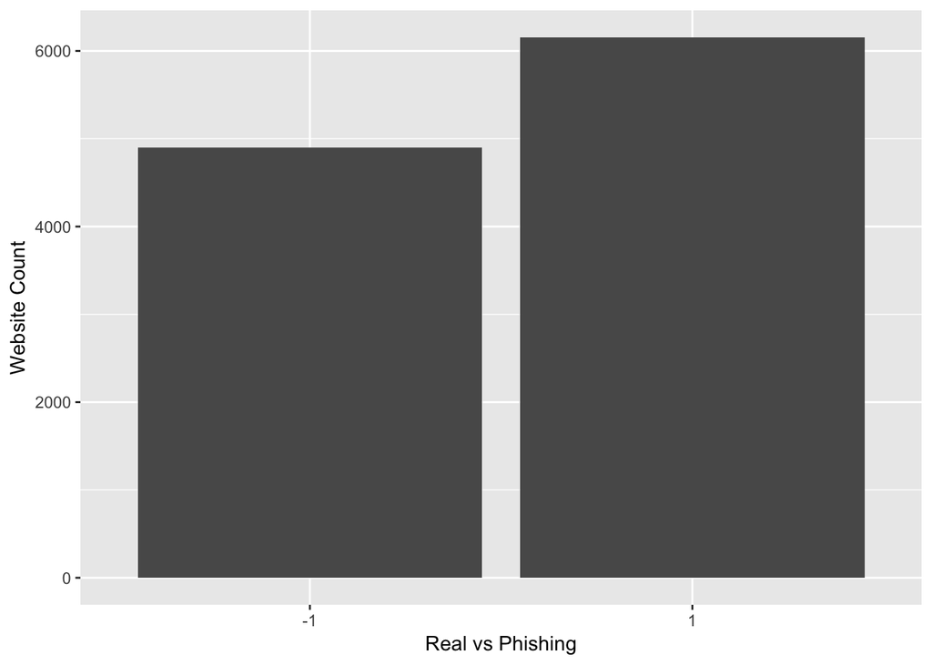

```r
#graphical analysis
ggplot(df, aes(x = Result)) +
  geom_bar() +
  xlab(label = "Real vs Phishing") +
  ylab(label = "Website Count")
```

In this code block we are preparing our data for use in machine learning algorithms.

### Data Management

- Randomize your dataset
- Break into test and train datasets
- Check and ensure that test and train datasets are similar

```r
#Data Prep for models

#randomize
df_rand <- df[sample(nrow(df)),]

# #Sample Indexes
indexes = sample(1:nrow(df_rand), size=0.25*nrow(df_rand))

# # Split data
df_test <- df_rand[indexes,]
dim(df_test)
```

```
## [1] 2763   31
```

```r
df_train <- df_rand[-indexes,]
dim(df_train)
```

```
## [1] 8292   31
```

```r
summary(df_train)
```

```
##  having_IP_Address URL_Length Shortening_Service having_At_Symbol
##  -1:2857           -1:6726    -1:1096            -1:1240
##  1 :5435           0 : 108    1 :7196            1 :7052
##                    1 :1458
##  double_slash_redirecting Prefix_Suffix having_Sub_Domain SSLfinal_State
##  -1:1079                  -1:7220       -1:2511           -1:2663
##  1 :7213                  1 :1072       0 :2737           0 : 871
##                                         1 :3044           1 :4758
##  Domain_registration_length Favicon   port      HTTPS_token Request_URL
##  -1:5520                    -1:1549   -1:1133   -1:1356     -1:3364
##  1 :2772                    1 :6743   1 :7159   1 :6936     1 :4928
##
##  URL_of_Anchor Links_in_tags SFH       Submitting_to_email Abnormal_URL
##  -1:2438       -1:2980       -1:6342   -1:1513             -1:1244
##  0 :4029       0 :3341       0 : 575   1 :6779             1 :7048
##  1 :1825       1 :1971       1 :1375
##  Redirect on_mouseover RightClick popUpWindow Iframe    age_of_domain
##  0:7310   -1: 993      -1: 355    -1:1619     -1: 769   -1:3884
##  1: 982   1 :7299      1 :7937    1 :6673     1 :7523   1 :4408
##
##  DNSRecord web_traffic Page_Rank Google_Index Links_pointing_to_page
##  -1:2610   -1:1977     -1:6135   -1:1161      -1: 408
##  1 :5682   0 :1943     1 :2157   1 :7131      0 :4606
##            1 :4372                            1 :3278
##  Statistical_report Result
##  -1:1170            -1:3653
##  1 :7122            1 :4639
##
```

```r
summary(df_test)
```

```
##  having_IP_Address URL_Length Shortening_Service having_At_Symbol
##  -1: 936           -1:2234    -1: 348            -1: 415
##  1 :1827           0 :  27    1 :2415            1 :2348
##                    1 : 502
##  double_slash_redirecting Prefix_Suffix having_Sub_Domain SSLfinal_State
##  -1: 350                  -1:2370       -1: 852           -1: 894
##  1 :2413                  1 : 393       0 : 885           0 : 296
##                                         1 :1026           1 :1573
##  Domain_registration_length Favicon   port      HTTPS_token Request_URL
##  -1:1869                    -1: 504   -1: 369   -1: 440     -1:1131
##  1 : 894                    1 :2259   1 :2394   1 :2323     1 :1632
##
##  URL_of_Anchor Links_in_tags SFH       Submitting_to_email Abnormal_URL
##  -1: 844       -1: 976       -1:2098   -1: 501             -1: 385
##  0 :1308       0 :1108       0 : 186   1 :2262             1 :2378
##  1 : 611       1 : 679       1 : 479
##  Redirect on_mouseover RightClick popUpWindow Iframe    age_of_domain
##  0:2466   -1: 322      -1: 121    -1: 518     -1: 243   -1:1305
##  1: 297   1 :2441      1 :2642    1 :2245     1 :2520   1 :1458
##
##  DNSRecord web_traffic Page_Rank Google_Index Links_pointing_to_page
##  -1: 833   -1: 678     -1:2066   -1: 378      -1: 140
##  1 :1930   0 : 626     1 : 697   1 :2385      0 :1550
##            1 :1459                            1 :1073
##  Statistical_report Result
##  -1: 380            -1:1245
##  1 :2383            1 :1518
##
```

```r
#Thanks to randomization, it appears that the proportion of -1 to 1 responses where there are two level factors is about equal across the columns.
```